# Uganda Performance Indicators

Francisco Rios Casas

10/29/2019

## 1. Introduction

This document highlights the data completeness, data sources, and changes over time for Outcome Indicators in Uganda. Data for indicators all came from the latest available Progress Update and Disbursement Request forms (PUDRs) indicated below:

| Most Recent PUDRs available |
| --- |
| Final LFA reviewed UGA-M-MoFPED PUDR.xlsx |
| UGA-M-TASO PUDR Jul-Dec18.xlsx |
| UGA-H-MoFPED Progress Update Report Jan-Jun 2019.xlsx |
| LFA Reviewed UGA-C-TASO PE 31Dec18.xlsx |
| LFA Reviewed UGA-T-MOFPED PE 31 Dec 2019 (10 May 2019).xlsx |

## 2. Data Completeness

For each Outcome Indicator, the grant Principal Recipient (PR) *usually* must establish an indicator “Baseline Value”. This value–when available–can serve as a benchmark for progress reported in subsequent time periods.

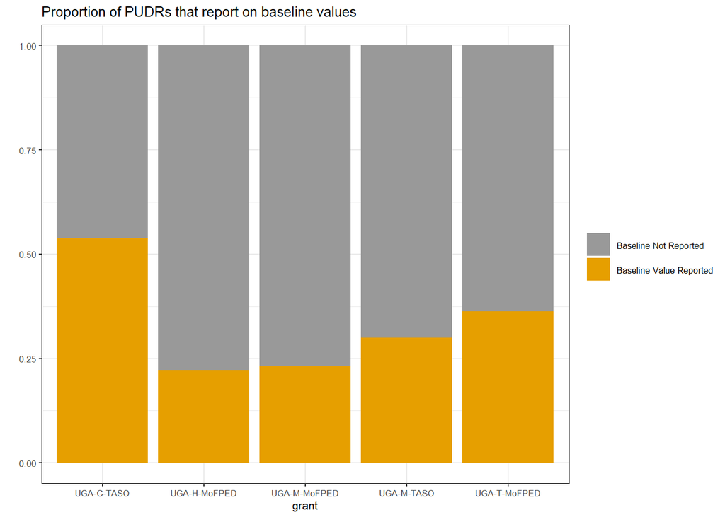

In order to calculate the achievement of an Outcome Indicator for a given grant, it is necessary to have information on (1) the target that was originally set and (2) the result.

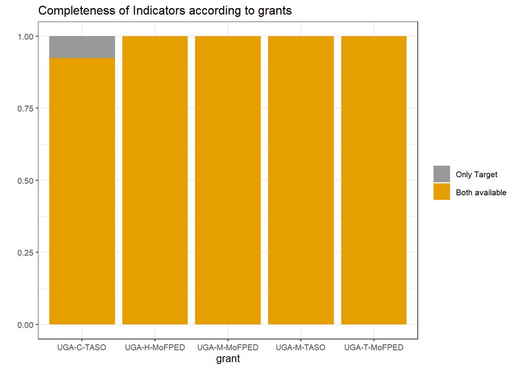

## 3. Data Sources

“Data Sources” are listed in the PUDR to indicate where information reported to the global fund came from. Examples of data sources include reports from the disease-specific National Programs, surveys such as the Demographic Health Survey (DHS), and Health Management Information systems such as DHIS2.

| Grant | Indicators | Different Sources between Baseline and Result |
| --- | --- | --- |
| UGA-M-MoFPED | 13 | 4 |
| UGA-M-TASO | 10 | 5 |
| UGA-H-MoFPED | 9 | 0 |
| UGA-C-TASO | 13 | 4 |
| UGA-T-MoFPED | 11 | 6 |

## 4. Grant Results based on most recent PUDRs

The “Achievement Ratio” is calculated in the PUDR to understand how close to the original target the Outcome Indicator result is. A value of 1.0 or greater means that the Indicators goal has been met or exceeded.

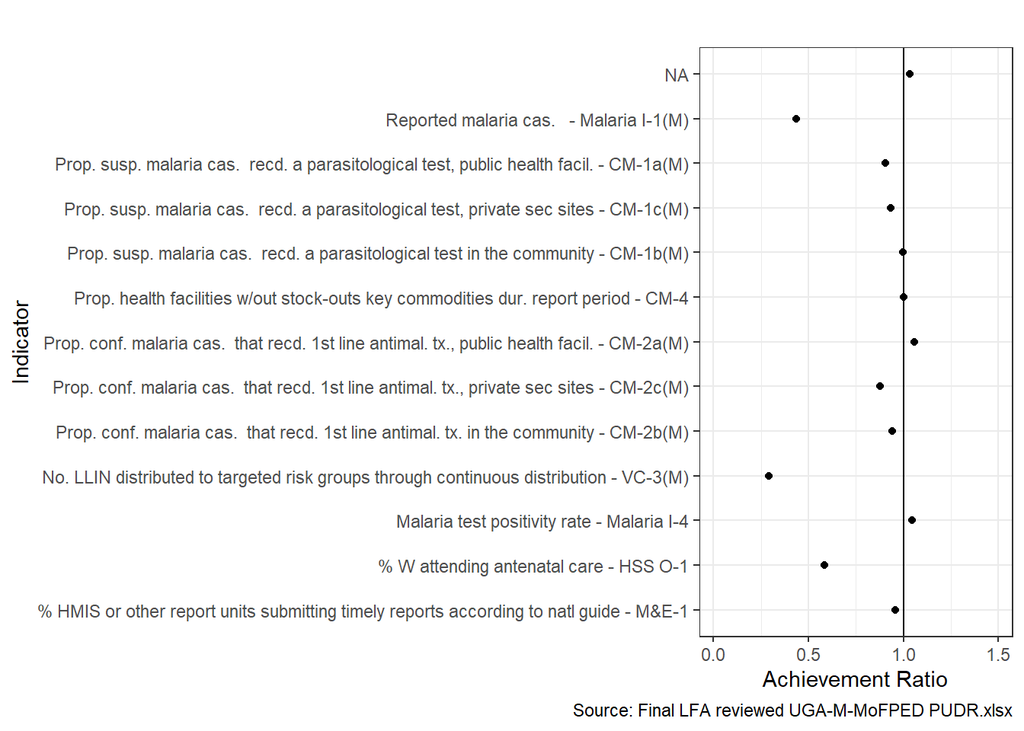

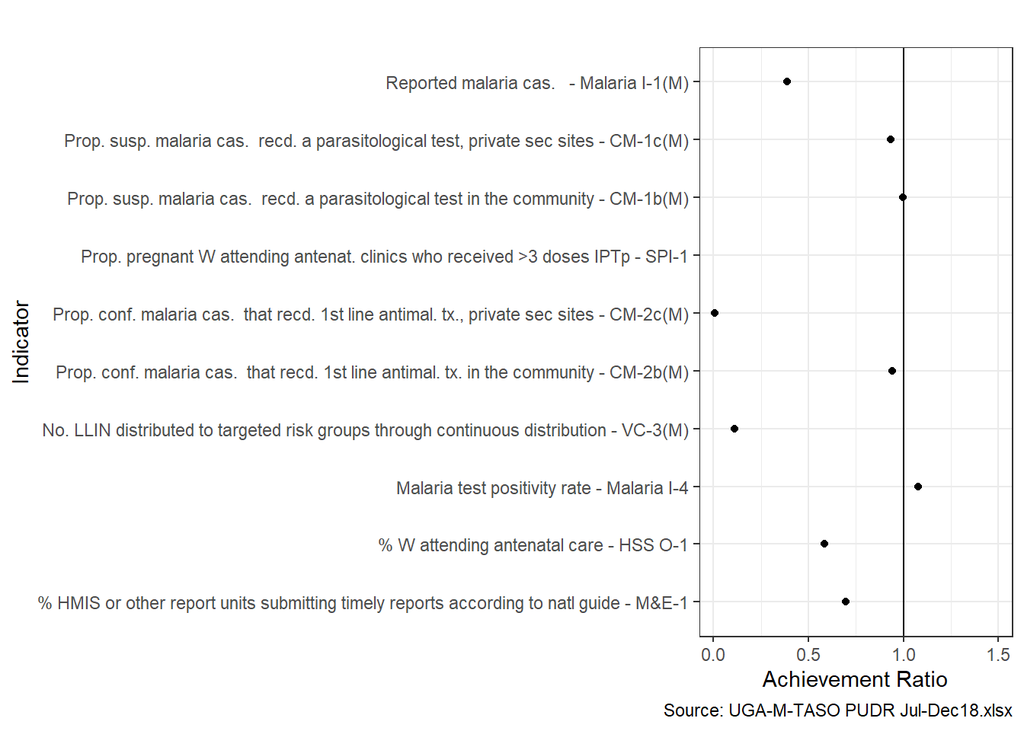

### 4.2

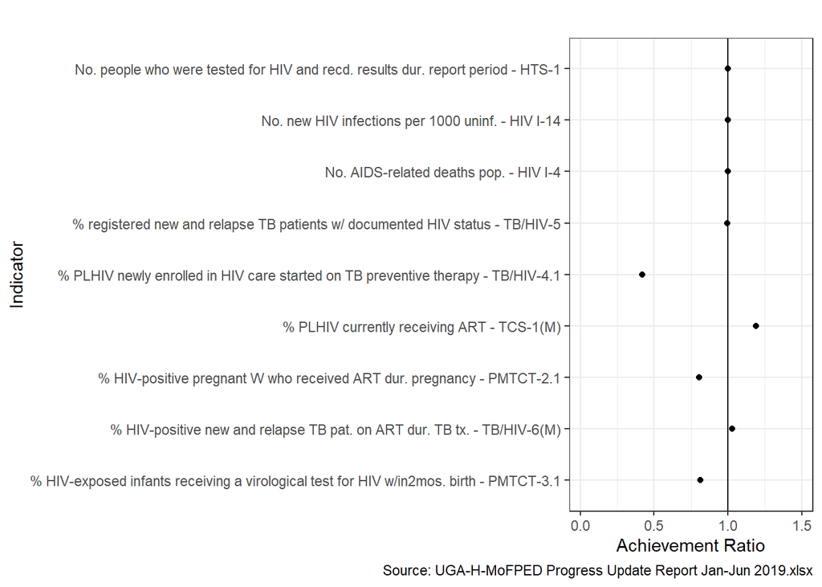

### 4.3

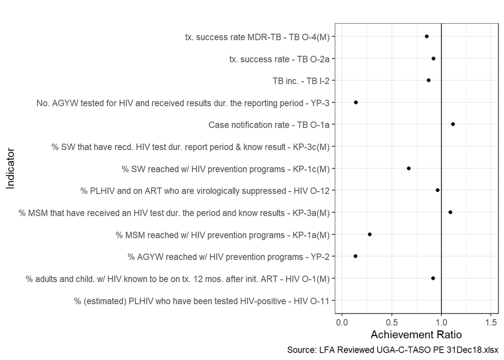

## 5. Agreement between PR, LFA

After each PUDR is submitted by the PR, the LFA will verify the results reported on the Indicators. In some cases they may revise the original values provided by the PR.

The most recent LFA-verified PUDRs for this analysis include the following:

| LFA Verified PUDR Files |
| --- |
| Final LFA reviewed UGA-M-MoFPED PUDR.xlsx |
| Final LFA reviewed UGA-M-TASO PUDR 2 Oct 2018.xlsx |
| LFA Reviewed UGA-H-MoFPED PUDR PE 31 Dec 18 (10 May 19).xlsx |
| LFA Reviewed UGA-C-TASO PE 31Dec18.xlsx |
| LFA Reviewed UGA-T-MOFPED PE 31 Dec 2019 (10 May 2019).xlsx |

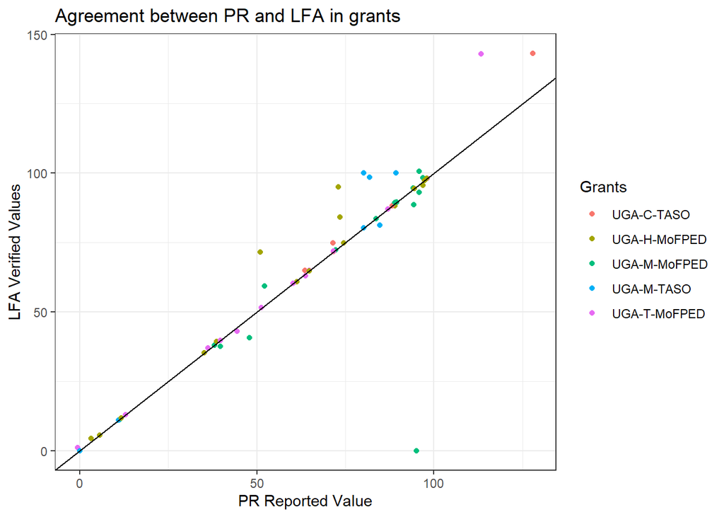

## 6. Results Over Time

The tables below highlights how indicators available in the three most recent PUDRs have changed over time for each of the grants.

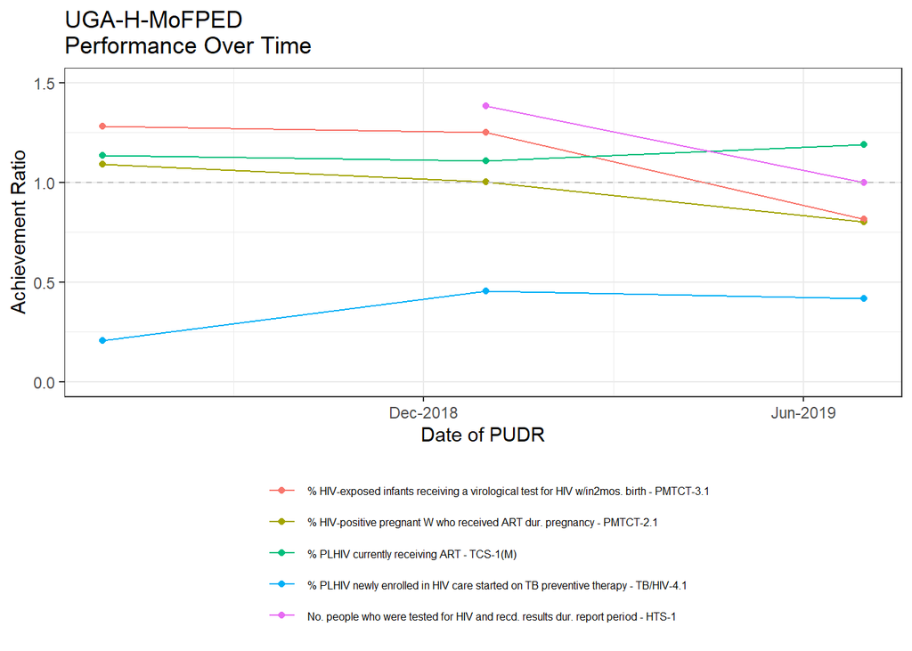

```
## geom_path: Each group consists of only one observation. Do you need to
## adjust the group aesthetic?
```

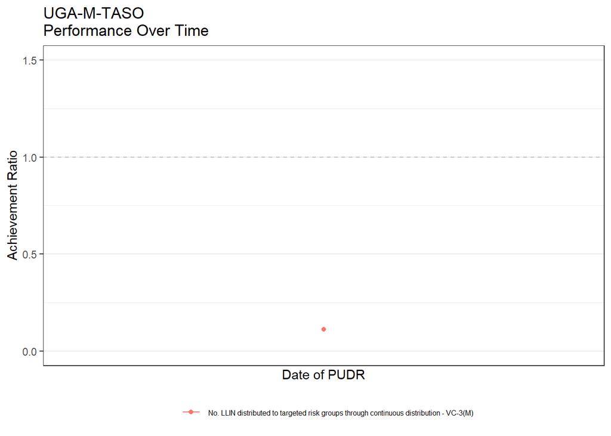

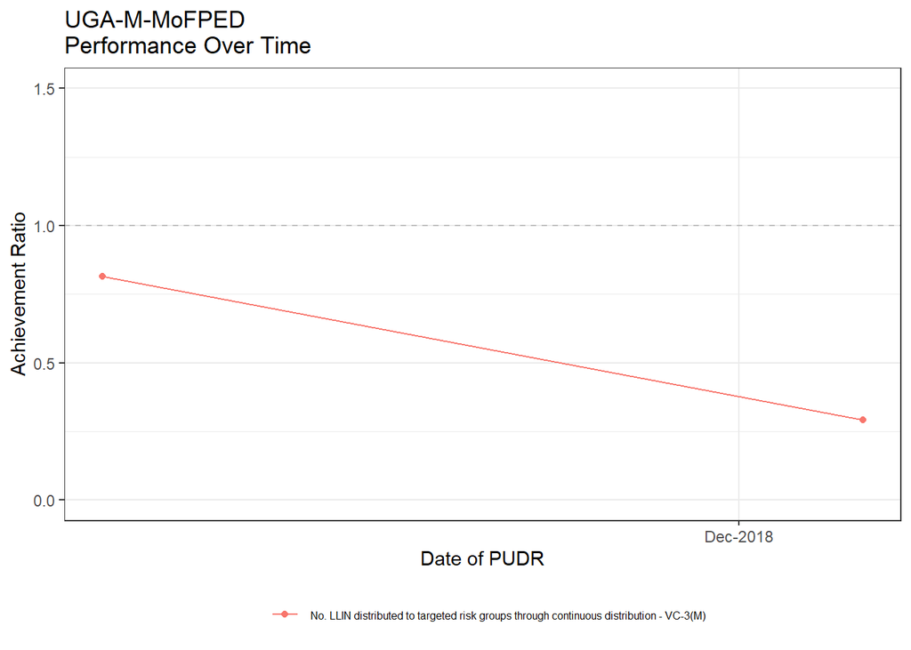